# Flight Data Project

Albert Perez

11/4/2021

# Airline Travel Exploratory Data Analysis Project

## Context

I am currently working for a fictional company called Paste Marketing which aims to help airline companies map out their data for stakeholders to help them generate business/data-driven decisions. Imagine an outside client hired us to find data that can help airlines decide whether we can find ways to increase customer satisfaction by analyzing the delay and arrival times. Our client works in a site in Washington and wants to know what our departure and arrival delay data dictates and how we can use it to improve customer experience on flights to California.

## Purpose

This project will focus on flight time quality and how we can use the data to predict when we have the worst and best flights. It should help airlines decide how to boost creative processes during delays to keep customers satisfied during different periods.

## Stakeholders

The stakeholders for this project are the airline companies which could potentially help them to push their marketing in WA and our client.

## Data Preparation

The data was collected from the Bureau of Transportation Statistics Tran Stats search tool. It will be stored locally on my desktop for further use. It will be stored in the following data formats “2021_date.csv”. The data can be classified as primary data as it generates the information right from the source.

Some information about the data that will help when visualizing the information.

The Airline will be classified under the OP_Unique_Carrier. Each airline has it’s own code. For this project, we will be using specific airlines in the US: 1. United Airlines-> UA 2. Delta Airlines -> DL 3. Southwest Airlines-> WN 4. JetBlue Airways -> B6 5. American Airlines -> AA 6. Hawaiian Airlines -> HA 7. Spirit Airlines -> NK 8. Frontier Airlines-> F9 9. Allegiant Airlines -> G4 10. Alaska Airlines -> AS

https://www.bts.gov/

### Loading the tools needed for the project:

```r
library(dplyr)
```

```r
library(ggplot2)
library(readr)
library(scales)
library(tidyr)
```

#### Dataframe

```r
data_frame(all_flights)
```

```
## # A tibble: 5,041,004 × 22
##     YEAR MONTH OP_UNIQUE_CARRIER ORIGIN_AIRPORT_ID ORIGIN_AIRPORT_SEQ_ID
##    <dbl> <dbl> <chr>                         <dbl>                 <dbl>
##  1  2020     8 WN                            11292               1129202
##  2  2020     8 WN                            11292               1129202
##  3  2020     8 WN                            11292               1129202
##  4  2020     8 WN                            11292               1129202
##  5  2020     8 WN                            11292               1129202
##  6  2020     8 WN                            11292               1129202
##  7  2020     8 WN                            11292               1129202
##  8  2020     8 WN                            11292               1129202
##  9  2020     8 WN                            11292               1129202
## 10  2020     8 WN                            11292               1129202
## # … with 5,040,994 more rows, and 17 more variables:
## #   ORIGIN_CITY_MARKET_ID <dbl>, ORIGIN <chr>, ORIGIN_CITY_NAME <chr>,
## #   ORIGIN_STATE_ABR <chr>, DEST_AIRPORT_ID <dbl>, DEST_AIRPORT_SEQ_ID <dbl>,
## #   DEST_CITY_MARKET_ID <dbl>, DEST <chr>, DEST_CITY_NAME <chr>,
## #   DEST_STATE_ABR <chr>, DEP_TIME <chr>, DEP_DELAY <dbl>, ARR_TIME <chr>,
## #   ARR_DELAY <dbl>, CANCELLED <dbl>, DISTANCE <dbl>, ...22 <lgl>
```

#### Variables

```r
names(all_flights)
```

```
##  [1] "YEAR"                  "MONTH"                 "OP_UNIQUE_CARRIER"
##  [4] "ORIGIN_AIRPORT_ID"     "ORIGIN_AIRPORT_SEQ_ID" "ORIGIN_CITY_MARKET_ID"
##  [7] "ORIGIN"                "ORIGIN_CITY_NAME"      "ORIGIN_STATE_ABR"
## [10] "DEST_AIRPORT_ID"       "DEST_AIRPORT_SEQ_ID"   "DEST_CITY_MARKET_ID"
## [13] "DEST"                  "DEST_CITY_NAME"        "DEST_STATE_ABR"
## [16] "DEP_TIME"              "DEP_DELAY"             "ARR_TIME"
## [19] "ARR_DELAY"             "CANCELLED"             "DISTANCE"
## [22] "...22"
```

```r
str(all_flights)
```

```
## spec_tbl_df [5,041,004 × 22] (S3: spec_tbl_df/tbl_df/tbl/data.frame)
##  $ YEAR                 : num [1:5041004] 2020 2020 2020 2020 2020 2020 2020 2020 2020 2020 ...
##  $ MONTH                : num [1:5041004] 8 8 8 8 8 8 8 8 8 8 ...
##  $ OP_UNIQUE_CARRIER    : chr [1:5041004] "WN" "WN" "WN" "WN" ...
##  $ ORIGIN_AIRPORT_ID    : num [1:5041004] 11292 11292 11292 11292 11292 ...
##  $ ORIGIN_AIRPORT_SEQ_ID: num [1:5041004] 1129202 1129202 1129202 1129202 1129202 ...
##  $ ORIGIN_CITY_MARKET_ID: num [1:5041004] 30325 30325 30325 30325 30325 ...
##  $ ORIGIN               : chr [1:5041004] "DEN" "DEN" "DEN" "DEN" ...
##  $ ORIGIN_CITY_NAME     : chr [1:5041004] "Denver, CO" "Denver, CO" "Denver, CO" "Denver, CO" ...
##  $ ORIGIN_STATE_ABR     : chr [1:5041004] "CO" "CO" "CO" "CO" ...
##  $ DEST_AIRPORT_ID      : num [1:5041004] 10821 11042 11042 11066 11066 ...
##  $ DEST_AIRPORT_SEQ_ID  : num [1:5041004] 1082106 1104205 1104205 1106606 1106606 ...
##  $ DEST_CITY_MARKET_ID  : num [1:5041004] 30852 30647 30647 31066 31066 ...
##  $ DEST                 : chr [1:5041004] "BWI" "CLE" "CLE" "CMH" ...
##  $ DEST_CITY_NAME       : chr [1:5041004] "Baltimore, MD" "Cleveland, OH" "Cleveland, OH" "Columbus, OH" ...
##  $ DEST_STATE_ABR       : chr [1:5041004] "MD" "OH" "OH" "OH" ...
##  $ DEP_TIME             : chr [1:5041004] "1542" "1950" "1332" "1408" ...
##  $ DEP_DELAY            : num [1:5041004] -3 -5 -3 -7 -1 -3 0 0 -4 -2 ...
##  $ ARR_TIME             : chr [1:5041004] "2057" "0032" "1819" "1847" ...
##  $ ARR_DELAY            : num [1:5041004] -8 -8 -1 -8 5 -3 -17 -18 -15 -16 ...
##  $ CANCELLED            : num [1:5041004] 0 0 0 0 0 0 0 0 0 0 ...
##  $ DISTANCE             : num [1:5041004] 1491 1201 1201 1154 1154 ...
##  $ ...22                : logi [1:5041004] NA NA NA NA NA NA ...
##  - attr(*, "spec")=
##   .. cols(
##   ..   YEAR = col_double(),
##   ..   MONTH = col_double(),
##   ..   OP_UNIQUE_CARRIER = col_character(),
##   ..   ORIGIN_AIRPORT_ID = col_double(),
##   ..   ORIGIN_AIRPORT_SEQ_ID = col_double(),
##   ..   ORIGIN_CITY_MARKET_ID = col_double(),
##   ..   ORIGIN = col_character(),
##   ..   ORIGIN_CITY_NAME = col_character(),
##   ..   ORIGIN_STATE_ABR = col_character(),
##   ..   DEST_AIRPORT_ID = col_double(),
##   ..   DEST_AIRPORT_SEQ_ID = col_double(),
##   ..   DEST_CITY_MARKET_ID = col_double(),
##   ..   DEST = col_character(),
##   ..   DEST_CITY_NAME = col_character(),
##   ..   DEST_STATE_ABR = col_character(),
##   ..   DEP_TIME = col_character(),
##   ..   DEP_DELAY = col_double(),
##   ..   ARR_TIME = col_character(),
##   ..   ARR_DELAY = col_double(),
##   ..   CANCELLED = col_double(),
##   ..   DISTANCE = col_double(),
##   ..   ...22 = col_logical()
##   .. )
##  - attr(*, "problems")=<externalptr>
```

# Data Processing and Cleaning

The first step is to check for structural errors with the data set. After reviewing the Variables listed above, the data does not have any structural errors such as data type errors. Next, we duplicates, since the data has been merged from different data sets:

```r
wa_flights <- all_flights %>%
  distinct() %>%
  filter(ORIGIN_STATE_ABR=="WA") %>%
  filter(OP_UNIQUE_CARRIER %in% c("AS", "G4", "AA", "DL", "F9", "HA", " B6", "WM", "NK", "UA"))
```

This concludes the data cleaning process. We are ready to start the exploratory data analysis part of our project.

## Washington Flight Data

```r
names(wa_flights)
```

```
##  [1] "YEAR"                  "MONTH"                 "OP_UNIQUE_CARRIER"
##  [4] "ORIGIN_AIRPORT_ID"     "ORIGIN_AIRPORT_SEQ_ID" "ORIGIN_CITY_MARKET_ID"
##  [7] "ORIGIN"                "ORIGIN_CITY_NAME"      "ORIGIN_STATE_ABR"
## [10] "DEST_AIRPORT_ID"       "DEST_AIRPORT_SEQ_ID"   "DEST_CITY_MARKET_ID"
## [13] "DEST"                  "DEST_CITY_NAME"        "DEST_STATE_ABR"
## [16] "DEP_TIME"              "DEP_DELAY"             "ARR_TIME"
## [19] "ARR_DELAY"             "CANCELLED"             "DISTANCE"
## [22] "...22"
```

```r
str(wa_flights)
```

```
## tibble [87,622 × 22] (S3: tbl_df/tbl/data.frame)
##  $ YEAR                 : num [1:87622] 2020 2020 2020 2020 2020 2020 2020 2020 2020 2020 ...
##  $ MONTH                : num [1:87622] 8 8 8 8 8 8 8 8 8 8 ...
##  $ OP_UNIQUE_CARRIER    : chr [1:87622] "AA" "AA" "AA" "AA" ...
##  $ ORIGIN_AIRPORT_ID    : num [1:87622] 14747 14747 14747 14747 14747 ...
##  $ ORIGIN_AIRPORT_SEQ_ID: num [1:87622] 1474703 1474703 1474703 1474703 1474703 ...
##  $ ORIGIN_CITY_MARKET_ID: num [1:87622] 30559 30559 30559 30559 30559 ...
##  $ ORIGIN               : chr [1:87622] "SEA" "SEA" "SEA" "SEA" ...
##  $ ORIGIN_CITY_NAME     : chr [1:87622] "Seattle, WA" "Seattle, WA" "Seattle, WA" "Seattle, WA" ...
##  $ ORIGIN_STATE_ABR     : chr [1:87622] "WA" "WA" "WA" "WA" ...
##  $ DEST_AIRPORT_ID      : num [1:87622] 11057 11057 11057 11057 11057 ...
##  $ DEST_AIRPORT_SEQ_ID  : num [1:87622] 1105703 1105703 1105703 1105703 1105703 ...
##  $ DEST_CITY_MARKET_ID  : num [1:87622] 31057 31057 31057 31057 31057 ...
##  $ DEST                 : chr [1:87622] "CLT" "CLT" "CLT" "CLT" ...
##  $ DEST_CITY_NAME       : chr [1:87622] "Charlotte, NC" "Charlotte, NC" "Charlotte, NC" "Charlotte, NC" ...
##  $ DEST_STATE_ABR       : chr [1:87622] "NC" "NC" "NC" "NC" ...
##  $ DEP_TIME             : chr [1:87622] "0911" "1005" "1007" "0910" ...
##  $ DEP_DELAY            : num [1:87622] -6 -4 -2 -7 -3 -6 -2 -4 14 -8 ...
##  $ ARR_TIME             : chr [1:87622] "1709" "1803" "1823" "1707" ...
##  $ ARR_DELAY            : num [1:87622] -6 -15 5 -8 1 -21 -8 -4 31 20 ...
##  $ CANCELLED            : num [1:87622] 0 0 0 0 0 0 0 0 0 0 ...
##  $ DISTANCE             : num [1:87622] 2279 2279 2279 2279 2279 ...
##  $ ...22                : logi [1:87622] NA NA NA NA NA NA ...
```

# Analysis and Visualizations

The first part of the analysis is to get an idea of the basic statistics.

```r
summary(wa_flights)
```

```
##       YEAR          MONTH        OP_UNIQUE_CARRIER  ORIGIN_AIRPORT_ID
##  Min.   :2020   Min.   : 1.000   Length:87622       Min.   :10666
##  1st Qu.:2020   1st Qu.: 4.000   Class :character   1st Qu.:14747
##  Median :2021   Median : 6.000   Mode  :character   Median :14747
##  Mean   :2021   Mean   : 6.377                      Mean   :14534
##  3rd Qu.:2021   3rd Qu.: 9.000                      3rd Qu.:14747
##  Max.   :2021   Max.   :12.000                      Max.   :14747
##  ORIGIN_AIRPORT_SEQ_ID ORIGIN_CITY_MARKET_ID    ORIGIN
##  Min.   :1066602       Min.   :30559         Length:87622
##  1st Qu.:1474703       1st Qu.:30559         Class :character
##  Median :1474703       Median :30559         Mode  :character
##  Mean   :1453354       Mean   :30654
##  3rd Qu.:1474703       3rd Qu.:30559
##  Max.   :1474703       Max.   :34252
##  ORIGIN_CITY_NAME   ORIGIN_STATE_ABR   DEST_AIRPORT_ID DEST_AIRPORT_SEQ_ID
##  Length:87622       Length:87622       Min.   :10140   Min.   :1014005
##  Class :character   Class :character   1st Qu.:11298   1st Qu.:1129806
##  Mode  :character   Mode  :character   Median :12892   Median :1289208
##                                        Mean   :12793   Mean   :1279274
##                                        3rd Qu.:14107   3rd Qu.:1410702
##                                        Max.   :15376   Max.   :1537604
##  DEST_CITY_MARKET_ID     DEST           DEST_CITY_NAME     DEST_STATE_ABR
##  Min.   :30140       Length:87622       Length:87622       Length:87622
##  1st Qu.:30466       Class :character   Class :character   Class :character
##  Median :31650       Mode  :character   Mode  :character   Mode  :character
##  Mean   :31810
##  3rd Qu.:32575
##  Max.   :34828
##    DEP_TIME           DEP_DELAY          ARR_TIME           ARR_DELAY
##  Length:87622       Min.   : -48.000   Length:87622       Min.   : -74.000
##  Class :character   1st Qu.:  -8.000   Class :character   1st Qu.: -18.000
##  Mode  :character   Median :  -4.000   Mode  :character   Median :  -9.000
##                     Mean   :   1.159                      Mean   :  -4.368
##                     3rd Qu.:   0.000                      3rd Qu.:   1.000
##                     Max.   :2039.000                      Max.   :2046.000
##    CANCELLED    DISTANCE     ...22
##  Min.   :0   Min.   : 129   Mode:logical
##  1st Qu.:0   1st Qu.: 954   NA's:87622
##  Median :0   Median :1107
##  Mean   :0   Mean   :1387
##  3rd Qu.:0   3rd Qu.:1874
##  Max.   :0   Max.   :2724
```

For all Washington flights, we see a variety of averages across each variable, despite the string data types.

Let’s examine the departure delays for flights from Washington to California. This project will focus on flight time quality and how we can use the data to predict when we have the worst and best flights. It should help airlines decide how to boost creative processes during delays to keep customers satisfied during different periods.

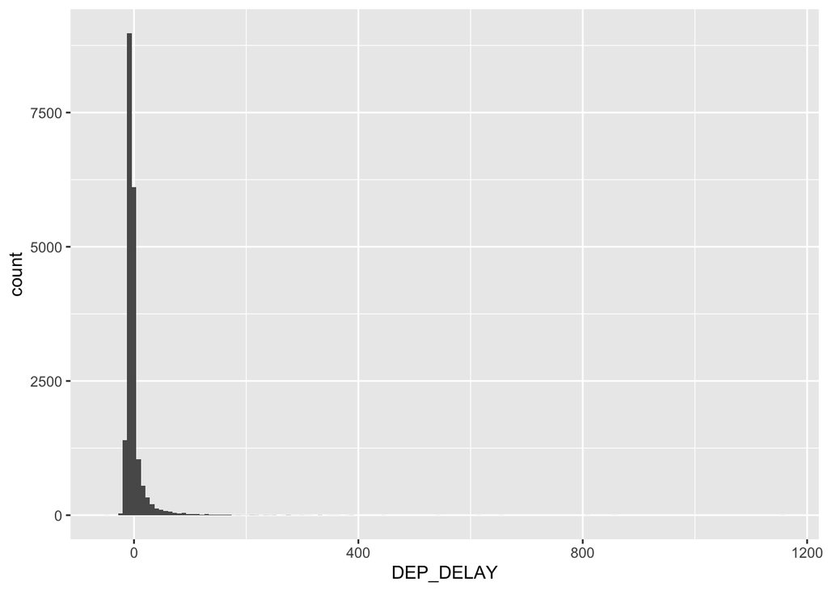

```r
ggplot(cal_flights, aes(x=DEP_DELAY))+
  geom_histogram(bins=150)+
  scale_y_continuous(labels = function(x) format(x, scientific=FALSE))
```

Where the mean, median, standard deviation, and IQR equates to:

```r
cal_flights %>%
  dplyr::summarise(cal_mean = mean(DEP_DELAY, na.rm = TRUE), cal_standard_deviation = sd(DEP_DELAY, na.rm = TRUE), cal_median=median(DEP_DELAY, na.rm = TRUE), cal_IQR = IQR(DEP_DELAY, na.rm = TRUE), cal_sample_size = n())
```

```
## # A tibble: 1 × 5
##   cal_mean cal_standard_deviation cal_median cal_IQR cal_sample_size
##      <dbl>                  <dbl>      <dbl>   <dbl>           <int>
## 1   -0.307                   25.6         -5       7           19343
```

Now lets look at arrival delays:

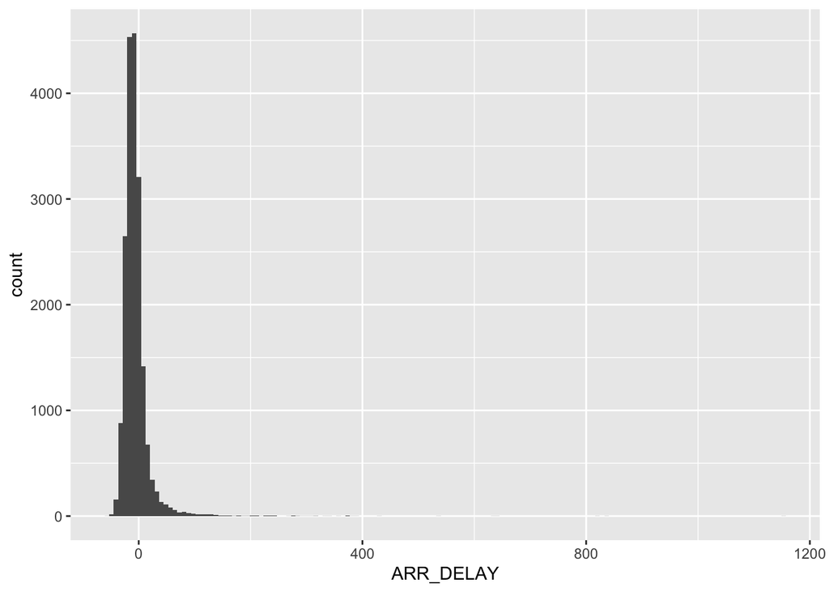

```r
ggplot(cal_flights, aes(x=ARR_DELAY))+
  geom_histogram(bins=150)+
  scale_y_continuous(labels = function(x) format(x, scientific=FALSE))
```

### Monthly Scatter Plot For Departure Delays

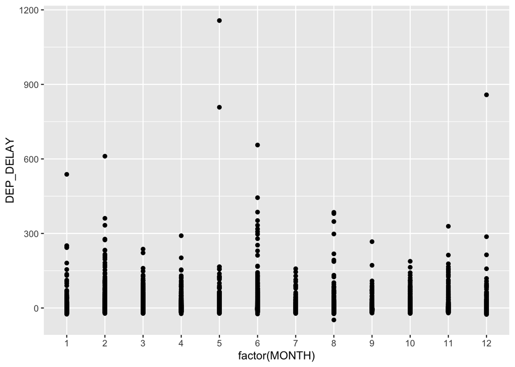

```r
ggplot(cal_flights, mapping=aes(x=factor(MONTH), y=DEP_DELAY))+
  geom_point()
```

### Scatter Plot for Arrival Delays

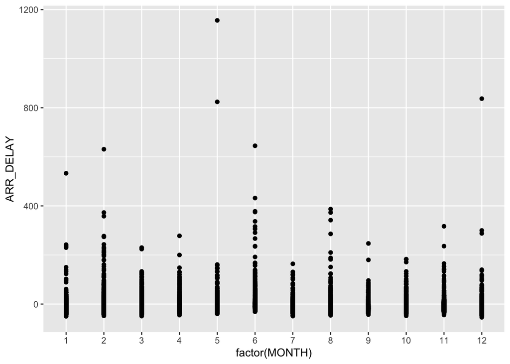

```r
ggplot(cal_flights, mapping=aes(x=factor(MONTH), y=ARR_DELAY))+
  geom_point()
```

```r
cal_flights %>%
  dplyr::summarise(cal_mean = mean(ARR_DELAY, na.rm = TRUE), cal_standard_deviation = sd(ARR_DELAY, na.rm = TRUE), cal_median=median(ARR_DELAY, na.rm = TRUE), cal_IQR = IQR(ARR_DELAY, na.rm = TRUE), cal_sample_size = n())
```

```
## # A tibble: 1 × 5
##   cal_mean cal_standard_deviation cal_median cal_IQR cal_sample_size
##      <dbl>                  <dbl>      <dbl>   <dbl>           <int>
## 1    -5.98                   28.0        -10      17           19343
```

Yearly Center of Mean Statistics:

```r
cal_flights %>%
  dplyr::summarise(cal_mean = mean(ARR_DELAY, na.rm = TRUE), cal_standard_deviation = sd(ARR_DELAY, na.rm = TRUE), cal_median=median(ARR_DELAY, na.rm = TRUE), cal_IQR = IQR(ARR_DELAY, na.rm = TRUE), cal_sample_size = n())
```

```
## # A tibble: 1 × 5
##   cal_mean cal_standard_deviation cal_median cal_IQR cal_sample_size
##      <dbl>                  <dbl>      <dbl>   <dbl>           <int>
## 1    -5.98                   28.0        -10      17           19343
```

```r
cal_flights %>%
  group_by(YEAR) %>%
  dplyr::summarise(cal_mean = mean(ARR_DELAY, na.rm = TRUE), cal_standard_deviation = sd(ARR_DELAY, na.rm = TRUE), cal_median=median(ARR_DELAY, na.rm = TRUE), cal_IQR = IQR(ARR_DELAY, na.rm = TRUE), cal_sample_size = n())
```

```
## # A tibble: 2 × 6
##    YEAR cal_mean cal_standard_deviation cal_median cal_IQR cal_sample_size
##   <dbl>    <dbl>                  <dbl>      <dbl>   <dbl>           <int>
## 1  2020    -9.16                   23.8        -12      16            7786
## 2  2021    -3.85                   30.4         -8      19           11557
```

### Monthly Mean:

```r
cal_flights %>%
  group_by(MONTH) %>%
  dplyr::summarise(cal_mean = mean(ARR_DELAY, na.rm = TRUE), cal_sample_size = n()) %>%
  arrange(desc(cal_mean))
```

```
## # A tibble: 12 × 3
##    MONTH cal_mean cal_sample_size
##    <dbl>    <dbl>           <int>
##  1     6     6.95            2051
##  2     8    -2.57            1199
##  3     2    -5.40            1647
##  4     4    -5.47            2059
##  5     3    -5.60            2230
##  6     5    -5.63            2080
##  7    11    -6.81            1398
##  8     1    -9.62            1490
##  9    10   -10.9             1444
## 10     7   -11.0              899
## 11     9   -11.4             1419
## 12    12   -11.8             1427
```

### Monthly Median

```r
cal_flights %>%
  group_by(MONTH) %>%
  dplyr::summarise(cal_median=median(ARR_DELAY, na.rm = TRUE), cal_sample_size = n()) %>%
  arrange(desc(cal_median))
```

```
## # A tibble: 12 × 3
##    MONTH cal_median cal_sample_size
##    <dbl>      <dbl>           <int>
##  1     6          0            2051
##  2     8         -6            1199
##  3     3         -8            2230
##  4     4         -9            2059
##  5     5         -9            2080
##  6    11        -10            1398
##  7     1        -13            1490
##  8     2        -13            1647
##  9     7        -14             899
## 10     9        -14            1419
## 11    10        -14            1444
## 12    12        -15            1427
```

### Monthly IQR

```r
cal_flights %>%
  group_by(MONTH) %>%
  dplyr::summarise(cal_IQR = IQR(ARR_DELAY, na.rm = TRUE), cal_sample_size = n()) %>%
  arrange(desc(cal_IQR))
```

```
## # A tibble: 12 × 3
##    MONTH cal_IQR cal_sample_size
##    <dbl>   <dbl>           <int>
##  1     2      21            1647
##  2     6      21            2051
##  3     3      18            2230
##  4    12      17            1427
##  5     1      16            1490
##  6     4      16            2059
##  7     5      16            2080
##  8    11      16            1398
##  9     8      15            1199
## 10     9      15            1419
## 11    10      14            1444
## 12     7      13             899
```

### Long and Short Departure Delays

We will indicate that any time over 10 minutes will be long delays and everything else will be short

```r
cal_flights <- cal_flights %>%
  mutate(long_short_dep = ifelse(DEP_DELAY< 10,"short", "long"))

dplyr::count(cal_flights, long_short_dep)
```

```
## # A tibble: 2 × 2
##   long_short_dep     n
##   <chr>          <int>
## 1 long            2079
## 2 short          17264
```

### Long and Short Arrival Delays

```r
cal_flights <- cal_flights %>%
  mutate(long_short_arr = ifelse(ARR_DELAY< 10,"short", "long"))

dplyr::count(cal_flights,long_short_arr)
```

```
## # A tibble: 2 × 2
##   long_short_arr     n
##   <chr>          <int>
## 1 long            2369
## 2 short          16974
```

### Comparison of Long vs Short Flights

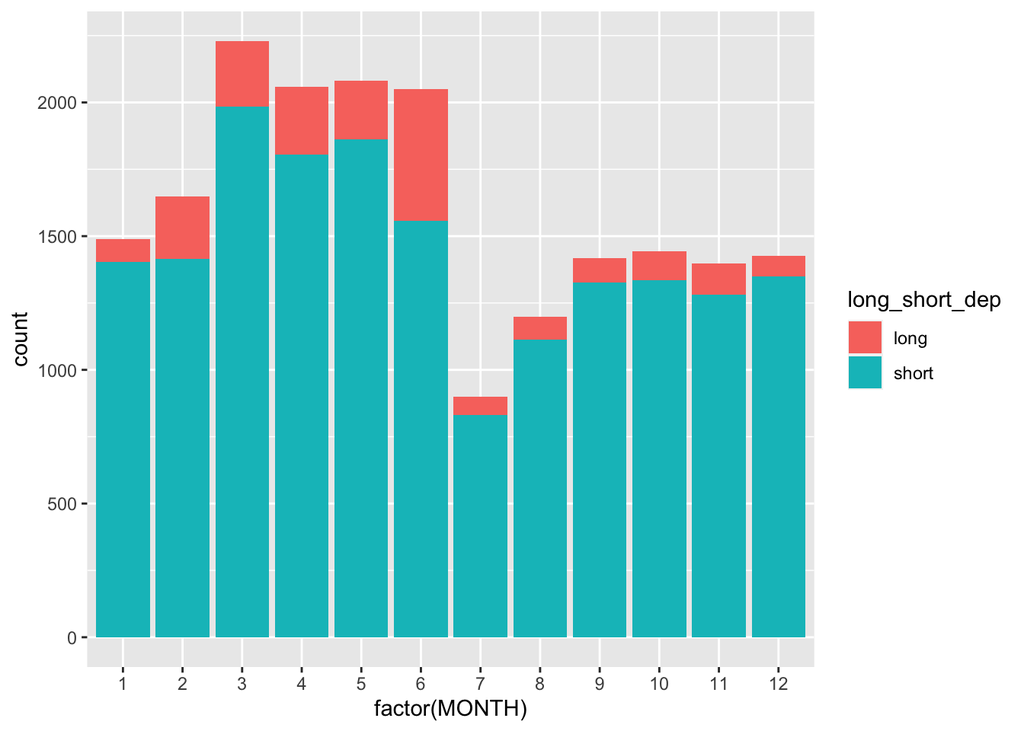

```r
ggplot(cal_flights, mapping = aes(x=factor(MONTH), fill=long_short_dep))+
  geom_bar()
```

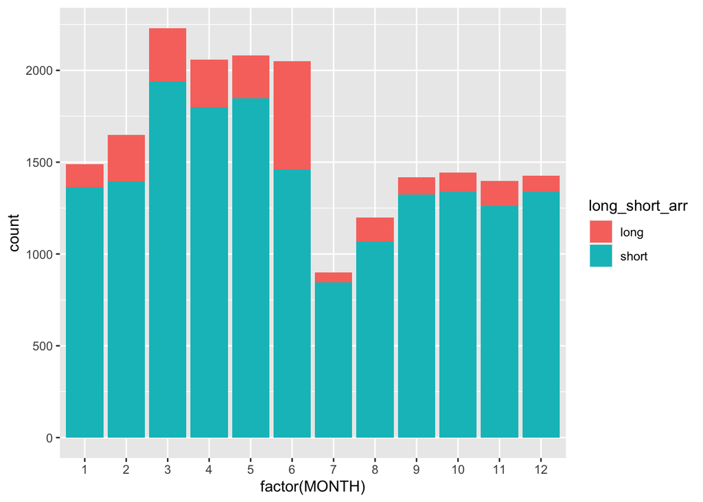

```r
ggplot(cal_flights, mapping = aes(x=factor(MONTH), fill=long_short_arr))+
  geom_bar()
```

### Do Flights have both a Long Arrival and Departure Delays

```r
cal_flights <- cal_flights %>%
  mutate(long_short_both = ifelse(long_short_dep=="long" & long_short_arr=="long","Yes", "No"))

dplyr::count(cal_flights,long_short_both)
```

```
## # A tibble: 2 × 2
##   long_short_both     n
##   <chr>           <int>
## 1 No              17855
## 2 Yes              1488
```

#### Graph

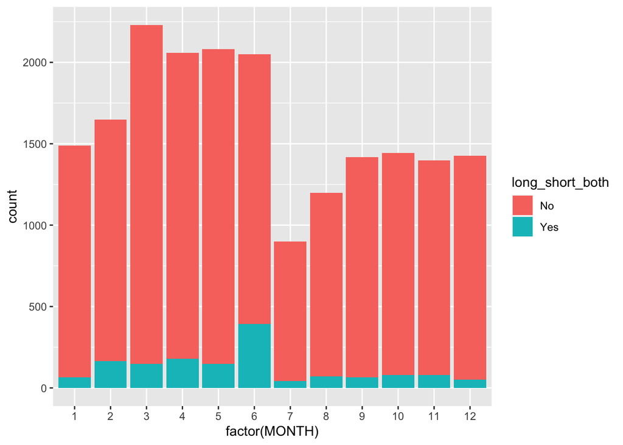

```r
ggplot(cal_flights, mapping = aes(x=factor(MONTH), fill=long_short_both))+
  geom_bar()
```

#Thank you for choosing PASTE Marketing.

## Citations

- This project was inspired by the Coursera Project in the Probability and Statistics course from Duke University.
- Bureau of Transportation Statistics: https://www.bts.gov/